# R Notebook

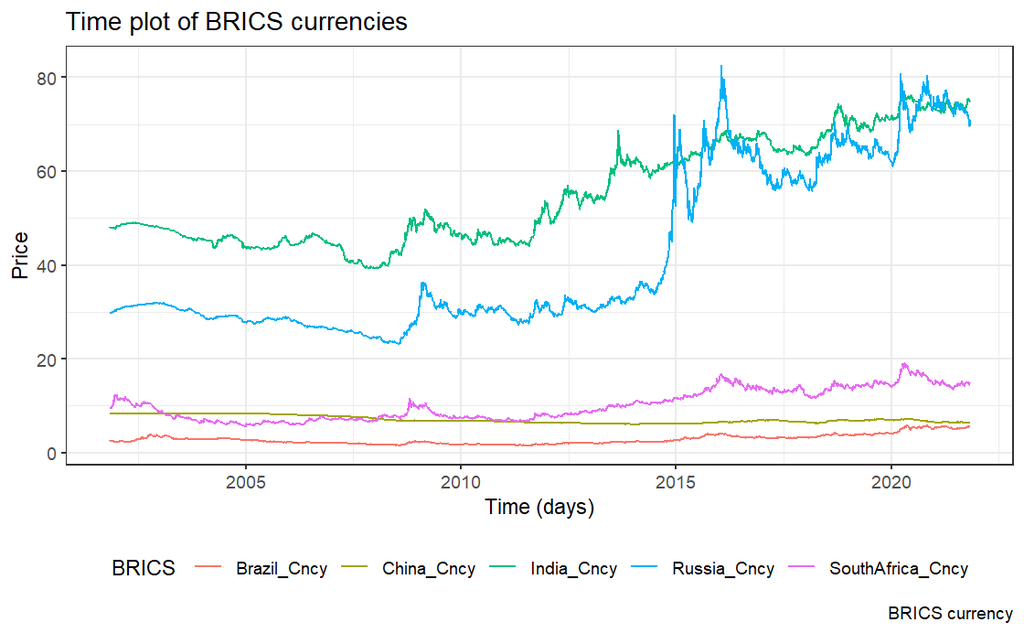

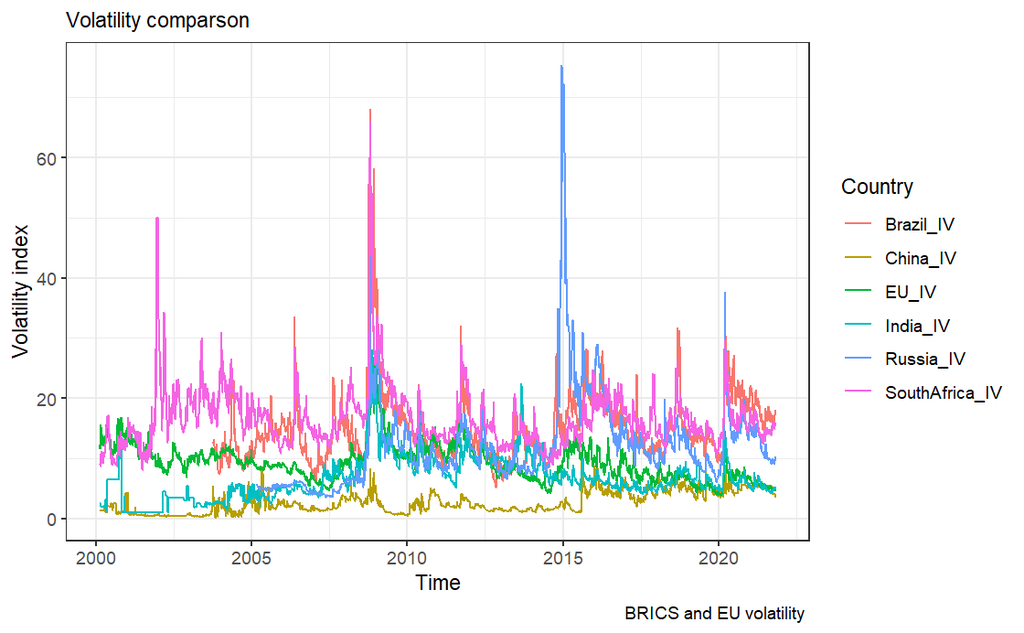

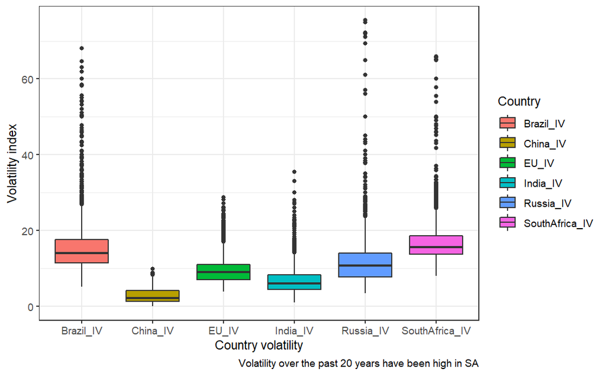

The diagram above with the statement that South Africa has a higher volatility over the past 20 years. This is evident as the volatility index (VI) has a distribution relatively higher than most BRICS countries, except Brazil perhaps. We also see that many periods had outliers, where the VI has spiked upwards.

```
Rows: 5,445
Columns: 3
$ date  <date> 2000-09-18, 2000-09-19, 2000-09-20, 2000-09-21, 2000-09-22, 2000-09-2~
$ Name  <chr> "DBHVG10U", "DBHVG10U", "DBHVG10U", "DBHVG10U", "DBHVG10U", "DBHVG10U"~
$ Price <dbl> 100.00, 99.53, 99.38, 99.31, 99.22, 99.86, 99.89, 100.11, 99.60, 99.57~
```

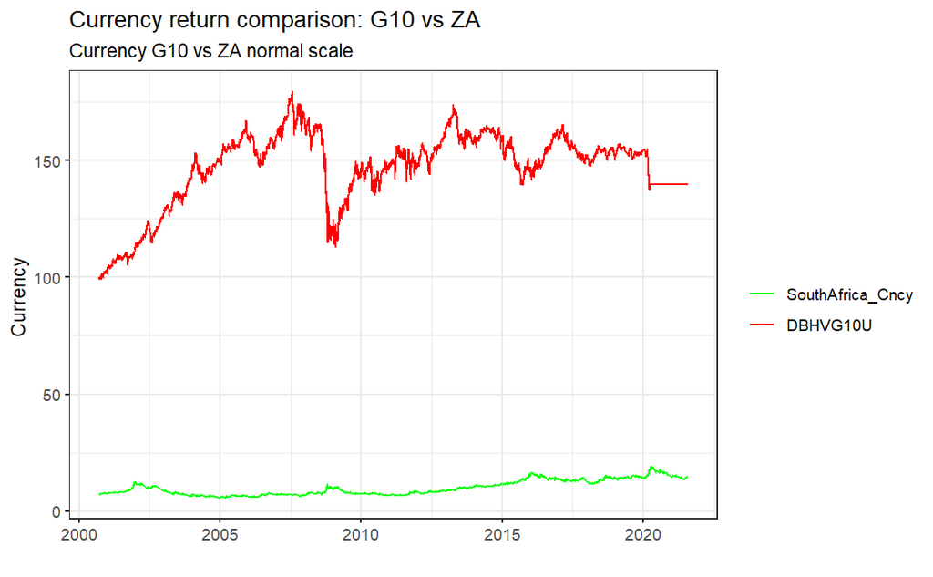

It is difficult to compare the SA and the G10 in `DBHVG10U` and South African currencies as they are on different scales. We can try to scale both measures to ensure that a fair comparison of their synchrony takes place.

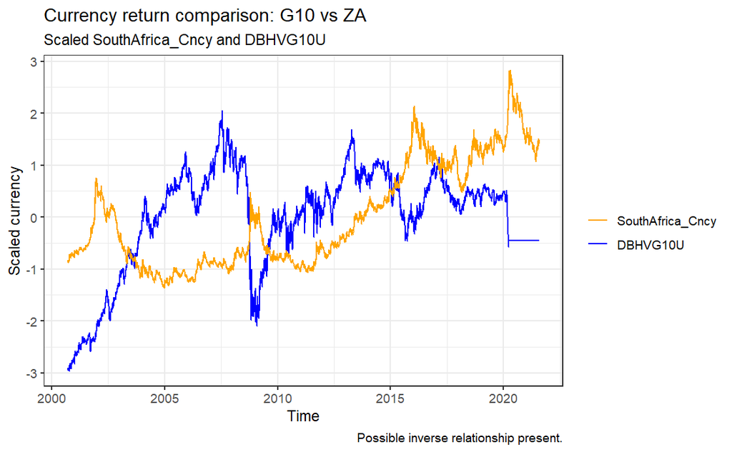

We observe from the scaled currencies a possible inverse relationship. In order to truly understand the synchrony of the currencies, we could use the correlation. This is the standard approach to consider the synchrony of two variables, but since this is also a time series problem, the time dimension is a factor in determining the correct approach. A rolling window has the added benefit of allowing you to include the time dimension but without eliminating the bias-variance trade-off in the window size. For more on this see work by Tsay in his 2013 book on multivariate time series.

[output not shown]

[output cut: 1406 more lines]

[output not shown]

```
NA
```

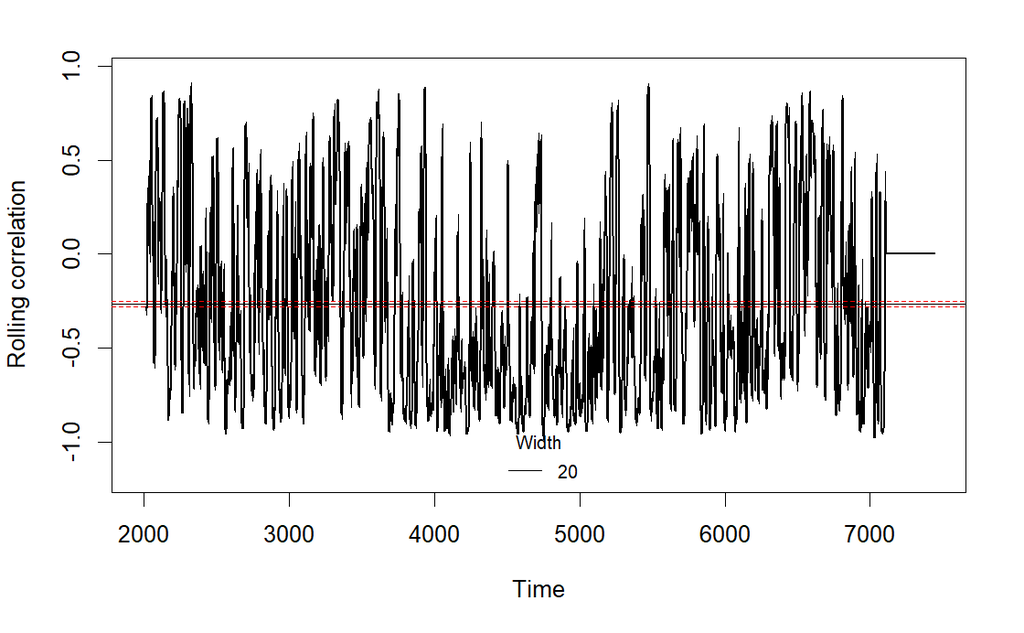

An analysis of the rolling correlation with a window showing the confidence interval, considering a 20 day window show that the correlation is generally slightly negative. Further supporting the argument that there is an inverse relationship, i.e. if ZA goes up, G10 goes down in general.